# FoodHub Data Analysis Project

### Context

The number of restaurants in New York is increasing day by day. Lots of students and busy professionals rely on those restaurants due to their hectic lifestyles. Online food delivery service is a great option for them. It provides them with good food from their favorite restaurants. A food aggregator company FoodHub offers access to multiple restaurants through a single smartphone app.

The app allows the restaurants to receive a direct online order from a customer. The app assigns a delivery person from the company to pick up the order after it is confirmed by the restaurant. The delivery person then uses the map to reach the restaurant and waits for the food package. Once the food package is handed over to the delivery person, he/she confirms the pick-up in the app and travels to the customer's location to deliver the food. The delivery person confirms the drop-off in the app after delivering the food package to the customer. The customer can rate the order in the app. The food aggregator earns money by collecting a fixed margin of the delivery order from the restaurants.

### Objective

The food aggregator company has stored the data of the different orders made by the registered customers in their online portal. They want to analyze the data to get a fair idea about the demand of different restaurants which will help them in enhancing their customer experience. Suppose you are hired as a Data Scientist in this company and the Data Science team has shared some of the key questions that need to be answered. Perform the data analysis to find answers to these questions that will help the company to improve the business.

### Data Description

The data contains the different data related to a food order. The detailed data dictionary is given below.

### Data Dictionary

- order_id: Unique ID of the order
- customer_id: ID of the customer who ordered the food
- restaurant_name: Name of the restaurant
- cuisine_type: Cuisine ordered by the customer
- cost: Cost of the order
- day_of_the_week: Indicates whether the order is placed on a weekday or weekend (The weekday is from Monday to Friday and the weekend is Saturday and Sunday)
- rating: Rating given by the customer out of 5
- food_preparation_time: Time (in minutes) taken by the restaurant to prepare the food. This is calculated by taking the difference between the timestamps of the restaurant's order confirmation and the delivery person's pick-up confirmation.
- delivery_time: Time (in minutes) taken by the delivery person to deliver the food package. This is calculated by taking the difference between the timestamps of the delivery person's pick-up confirmation and drop-off information

### Let us start by importing the required libraries

```python
# import libraries for data manipulation
import numpy as np
import pandas as pd

# import libraries for data visualization
import matplotlib.pyplot as plt
import seaborn as sns
```

### Understanding the structure of the data

```python
# read the data
df = pd.read_csv('foodhub_order.csv')
# returns the first 5 rows
df.head()
```

|  | order_id | customer_id | restaurant_name | cuisine_type | cost_of_the_order | day_of_the_week | rating | food_preparation_time | delivery_time |
| --- | --- | --- | --- | --- | --- | --- | --- | --- | --- |
| 0 | 1477147 | 337525 | Hangawi | Korean | 30.75 | Weekend | Not given | 25 | 20 |
| 1 | 1477685 | 358141 | Blue Ribbon Sushi Izakaya | Japanese | 12.08 | Weekend | Not given | 25 | 23 |
| 2 | 1477070 | 66393 | Cafe Habana | Mexican | 12.23 | Weekday | 5 | 23 | 28 |
| 3 | 1477334 | 106968 | Blue Ribbon Fried Chicken | American | 29.20 | Weekend | 3 | 25 | 15 |
| 4 | 1478249 | 76942 | Dirty Bird to Go | American | 11.59 | Weekday | 4 | 25 | 24 |

```python
# investigate columns and their datatypes
df.info()
```

```
<class 'pandas.core.frame.DataFrame'>
RangeIndex: 1898 entries, 0 to 1897
Data columns (total 9 columns):
 #   Column                 Non-Null Count  Dtype
---  ------                 --------------  -----
 0   order_id               1898 non-null   int64
 1   customer_id            1898 non-null   int64
 2   restaurant_name        1898 non-null   object
 3   cuisine_type           1898 non-null   object
 4   cost_of_the_order      1898 non-null   float64
 5   day_of_the_week        1898 non-null   object
 6   rating                 1898 non-null   object
 7   food_preparation_time  1898 non-null   int64
 8   delivery_time          1898 non-null   int64
dtypes: float64(1), int64(4), object(4)
memory usage: 133.6+ KB
```

#### Observations:

The DataFrame has 9 columns as mentioned in the Data Dictionary. Data in each row corresponds to the order placed by a customer.

### **Question 1:** How many rows and columns are present in the data?

```python
# access how many rows(axis = 0) and columns(axis = 1) there are.
print("There are", df.shape[0], 'rows and', df.shape[1], "columns.")
```

```
There are 1898 rows and 9 columns.
```

#### Observations:

There are 1898 rows and 9 columns present in the data.

### **Question 2:** What are the datatypes of the different columns in the dataset? (The info() function can be used)

```python
# Use info() to print a concise summary of the DataFrame
df.info()
```

```
<class 'pandas.core.frame.DataFrame'>
RangeIndex: 1898 entries, 0 to 1897
Data columns (total 9 columns):
 #   Column                 Non-Null Count  Dtype
---  ------                 --------------  -----
 0   order_id               1898 non-null   int64
 1   customer_id            1898 non-null   int64
 2   restaurant_name        1898 non-null   object
 3   cuisine_type           1898 non-null   object
 4   cost_of_the_order      1898 non-null   float64
 5   day_of_the_week        1898 non-null   object
 6   rating                 1898 non-null   object
 7   food_preparation_time  1898 non-null   int64
 8   delivery_time          1898 non-null   int64
dtypes: float64(1), int64(4), object(4)
memory usage: 133.6+ KB
```

#### Observations:

The following columns are integers: order_id, customer_id, food_preparation_time, and delivery_time.

The only float column is cost_of_the_order.

The following columns are strings: restaurant_name, cuisine_type, day_of_the_week, and rating. I am wary of potentially having to work with ratings as integers or floats.

### **Question 3:** Are there any missing values in the data? If yes, treat them using an appropriate method.

```python
# find out if there are missing values or NaN in the data
df.isnull().sum()
```

```
order_id                 0
customer_id              0
restaurant_name          0
cuisine_type             0
cost_of_the_order        0
day_of_the_week          0
rating                   0
food_preparation_time    0
delivery_time            0
dtype: int64
```

```python
# find out if there are 0 (integer) in the data that need special attention
(df==0).sum()
```

```
order_id                 0
customer_id              0
restaurant_name          0
cuisine_type             0
cost_of_the_order        0
day_of_the_week          0
rating                   0
food_preparation_time    0
delivery_time            0
dtype: int64
```

```python
# find out if there are 0 (string) in the data that need special attention
(df=='0').sum()
```

```
order_id                 0
customer_id              0
restaurant_name          0
cuisine_type             0
cost_of_the_order        0
day_of_the_week          0
rating                   0
food_preparation_time    0
delivery_time            0
dtype: int64
```

```python
# looking through data, 'Not given' is a string value that is under 'rating' column.
(df=='Not given').sum()
```

```
order_id                   0
customer_id                0
restaurant_name            0
cuisine_type               0
cost_of_the_order          0
day_of_the_week            0
rating                   736
food_preparation_time      0
delivery_time              0
dtype: int64
```

```python
# copy original data and replace 'Not given' to 6
df_treated = df.copy()
df_treated['rating'] = df_treated['rating'].replace(['Not given'], '6')
df_treated.head()
```

|  | order_id | customer_id | restaurant_name | cuisine_type | cost_of_the_order | day_of_the_week | rating | food_preparation_time | delivery_time |
| --- | --- | --- | --- | --- | --- | --- | --- | --- | --- |
| 0 | 1477147 | 337525 | Hangawi | Korean | 30.75 | Weekend | 6 | 25 | 20 |
| 1 | 1477685 | 358141 | Blue Ribbon Sushi Izakaya | Japanese | 12.08 | Weekend | 6 | 25 | 23 |
| 2 | 1477070 | 66393 | Cafe Habana | Mexican | 12.23 | Weekday | 5 | 23 | 28 |
| 3 | 1477334 | 106968 | Blue Ribbon Fried Chicken | American | 29.20 | Weekend | 3 | 25 | 15 |
| 4 | 1478249 | 76942 | Dirty Bird to Go | American | 11.59 | Weekday | 4 | 25 | 24 |

```python
# change datatype of 'rating' to int
df_treated['rating'] = df_treated['rating'].astype(int)
df_treated.dtypes
```

```
order_id                   int64
customer_id                int64
restaurant_name           object
cuisine_type              object
cost_of_the_order        float64
day_of_the_week           object
rating                     int32
food_preparation_time      int64
delivery_time              int64
dtype: object
```

```python
# create df_shorten that excludes the rows with "Not given" in 'rating'
df_shorten = df_treated[df_treated['rating']<6]
df_shorten.head()
```

|  | order_id | customer_id | restaurant_name | cuisine_type | cost_of_the_order | day_of_the_week | rating | food_preparation_time | delivery_time |
| --- | --- | --- | --- | --- | --- | --- | --- | --- | --- |
| 2 | 1477070 | 66393 | Cafe Habana | Mexican | 12.23 | Weekday | 5 | 23 | 28 |
| 3 | 1477334 | 106968 | Blue Ribbon Fried Chicken | American | 29.20 | Weekend | 3 | 25 | 15 |
| 4 | 1478249 | 76942 | Dirty Bird to Go | American | 11.59 | Weekday | 4 | 25 | 24 |
| 5 | 1477224 | 147468 | Tamarind TriBeCa | Indian | 25.22 | Weekday | 3 | 20 | 24 |
| 7 | 1477859 | 89574 | Barbounia | Mediterranean | 5.97 | Weekday | 3 | 33 | 30 |

#### Observations:

Since the only type of missing values are 736 "Not given"s in ratings, I decided to change those values to 6, which is outside of the possible inputs. This avoids the potential confusion where the rating of 0 will be equated with missing ratings.

From here, I will be using df_treated for when I need ratings to be integers, and df_shorten for leaving out rows with "Not given" in 'rating'.

### **Question 4:** Check the statistical summary of the data. What is the minimum, average, and maximum time it takes for food to be prepared once an order is placed?

```python
# access the statistical summary of 'food_preparation_time'
df['food_preparation_time'].describe()
```

```
count    1898.000000
mean       27.371970
std         4.632481
min        20.000000
25%        23.000000
50%        27.000000
75%        31.000000
max        35.000000
Name: food_preparation_time, dtype: float64
```

```python
# access the statistical summary of the combined time between food preparation and delivered
(df['food_preparation_time']+df['delivery_time']).describe()
```

```
count    1898.000000
mean       51.533720
std         6.833603
min        35.000000
25%        47.000000
50%        52.000000
75%        56.000000
max        68.000000
dtype: float64
```

#### Observations:

If the food preparation before the delivery is considered only, then the minimum, average, and max time will be 20.00, 27.37, and 35.00 minutes, respectively.

If the delivery time is also taken into account, then the minimum, average, and max time of preparation will be 35.00, 51.53, and 68.00 minutes, respectively.

### **Question 5:** How many orders are not rated?

```python
# count how many rows have "Not given" as its rating.
len(df[df['rating']=='Not given'])
```

```
736
```

#### Observations:

There are 736 orders that are not rated.

### Exploratory Data Analysis (EDA)

### **Question 6:** Explore all the variables and provide observations on their distributions. (Generally, histograms, boxplots, countplots, etc. are used for univariate exploration.)

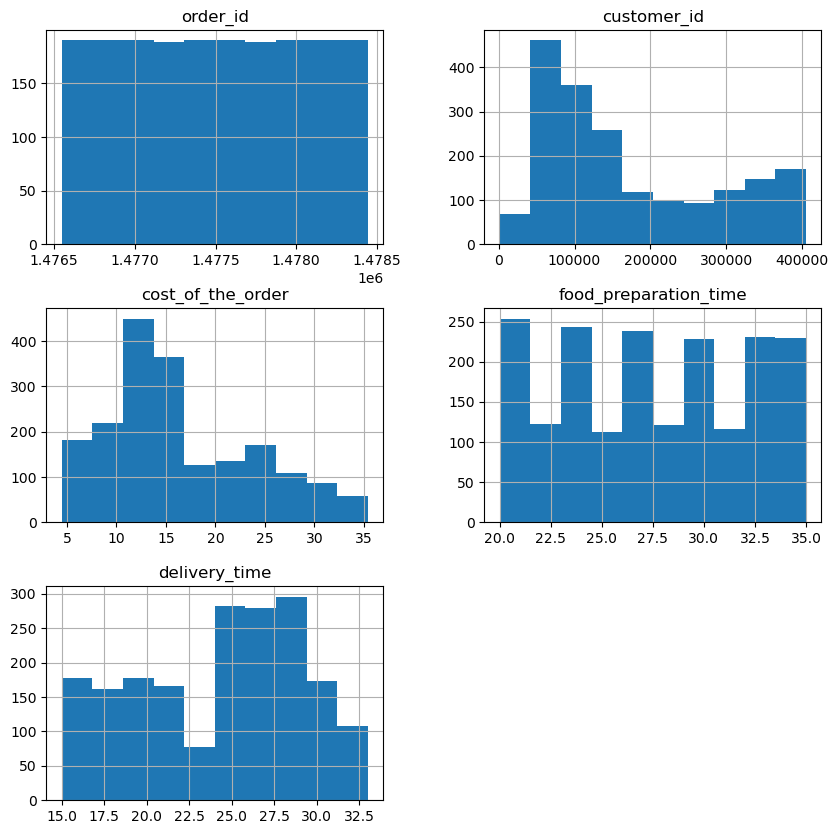

```python
# generate histograms of the numerical data ('rating' to be included later)
df.hist(figsize=(10,10));
```

As expected, order_id has uniform distribution because each number is used once. customer_id has a distribution that seems to be between skewed-right and multimodal but again, distribution analysis for id's is not that meaningful.

Let's look closely at other categories, starting with cost_of_the_order.

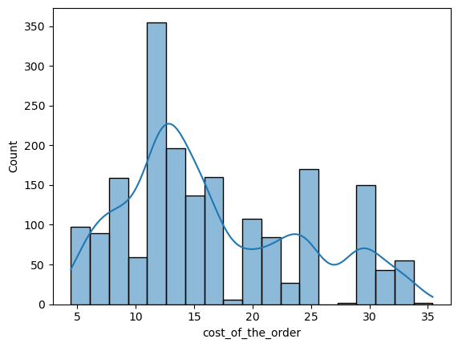

```python
# generate a histogram for cost_of_the_order
sns.histplot(data=df, x='cost_of_the_order', kde=True);
```

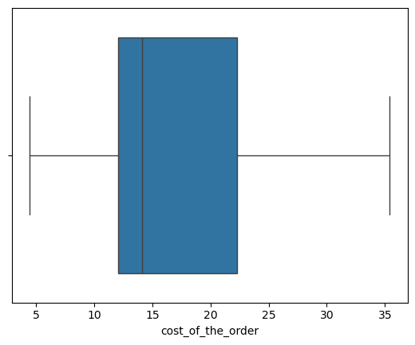

```python
# generate a boxplot for cost_of_the_order
sns.boxplot(data=df, x='cost_of_the_order');
```

#### Observations:

cost_of_the_order seems to have somewhat normal distribution but skewed to the right. It is interesting that the max for the cost is around 35 dollars, which may mean that most of the orders are only for single person each. The middle 50% (IQR) range from $12-22.

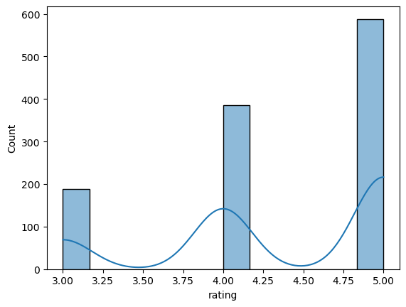

```python
# generate a histogram for 'rating'
sns.histplot(data=df_shorten, x='rating', kde=True);
```

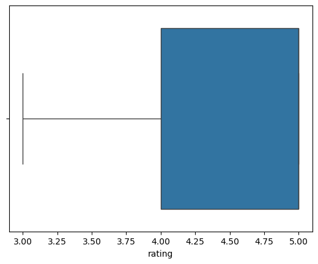

```python
# generate a boxplot for 'rating'
sns.boxplot(data=df_shorten, x='rating');
```

#### Observations:

Ratings range from 3 to 5 in this data set, which shows a generally favorable feedback from customers, although further investigation would help if 'Not given' ratings mean negative reviews or simple negligence.

There are 5 times as many reviews of 4 or 5 as there are reviews of 3.

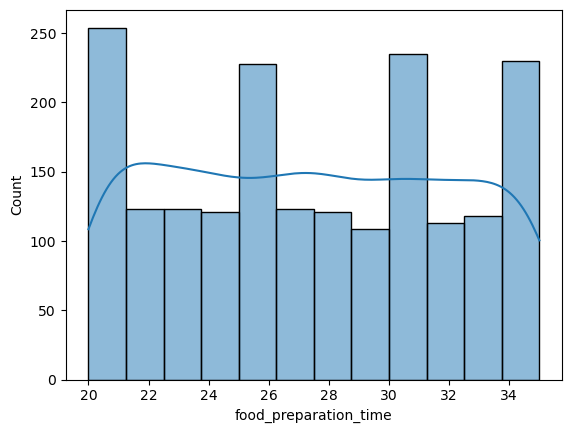

```python
# generate a histogram for 'food_preparation_time'
sns.histplot(data=df, x='food_preparation_time', kde=True);
```

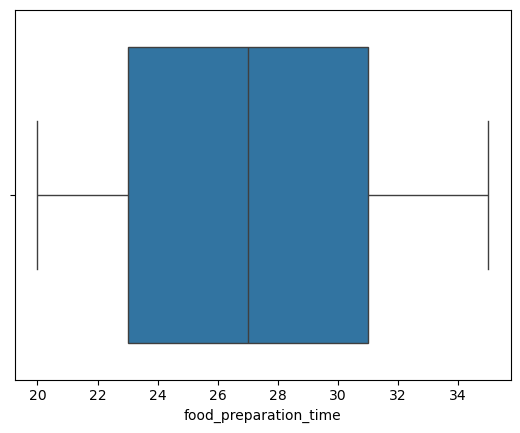

```python
# generate a boxplot for 'food_preparation_time'
sns.boxplot(data=df, x='food_preparation_time');
```

#### Observations:

Food preparation time shows a multimodal distribution where there are some spikes for certain values. It ranges between 20 and 35 minutes, which can be a long time especially because it is before the food is picked up to be delivered.

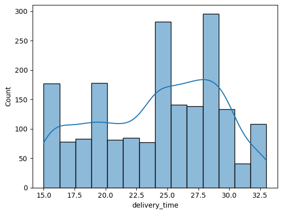

```python
# generate a histogram for 'delivery_time'
sns.histplot(data=df, x='delivery_time', kde=True);
```

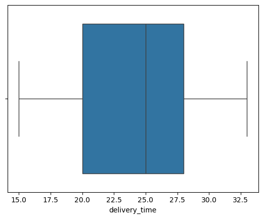

```python
# generate a boxplot for 'delivery_time'
sns.boxplot(data=df, x='delivery_time');
```

#### Observations:

Delivery time ranges from around 15 minutes to 33 minutes. It has a somewhat left-skew looking distribution, but still the first 50% and the second 50% of the data are evenly split around 25 minutes.

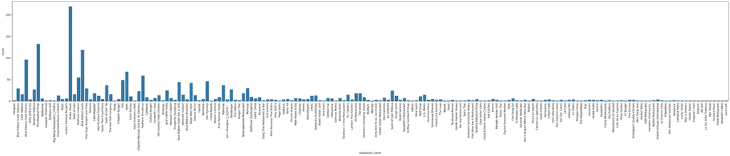

```python
# countplot of restaurants and their number of orders placed
plt.figure(figsize=(50,7))
sns.countplot(data=df, x='restaurant_name');
plt.xticks(rotation=90)
plt.show() #by clicking on the countplot, you can see the count for each restaurant
```

#### Observations:

Restaurant name countplot shows with ease some of the top restaurants in terms of the number of orders placed. Majority of the restaurants have very few orders placed within the scope of the data.

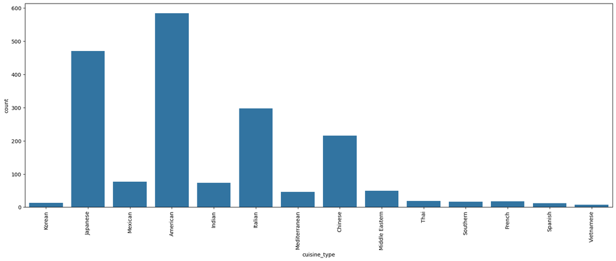

```python
# generate a countplot for 'cuisine_type'
plt.figure(figsize=(20,7))
sns.countplot(data=df, x='cuisine_type')
plt.xticks(rotation=90)
plt.show()
```

#### Observations:

This countplot shows at a glance some of the more popular cuisines ordered - American, Japanese, Italian, and Chinese.

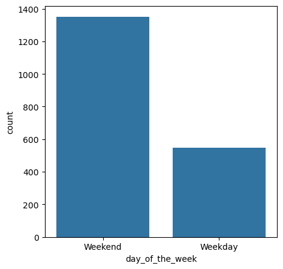

```python
# generate a countplot for 'day_of_the_week'
plt.figure(figsize=(5,5))
sns.countplot(data=df, x='day_of_the_week')
plt.show()
```

#### Observations:

The countplot shows that there is more than twice the amount of orders placed during the two weekend days than during the five weekdays. This is significant, and further delineation of 7 days may be even more helpful.

### **Question 7**: Which are the top 5 restaurants in terms of the number of orders received?

```python
# generate a groupby dataframe that is sorted by the number of orders
restaurant_orders = df.groupby('restaurant_name')['order_id'].count().reset_index()
sorted_restaurant_orders = restaurant_orders.sort_values('order_id', ascending=False)
sorted_restaurant_orders.head()
```

|  | restaurant_name | order_id |
| --- | --- | --- |
| 136 | Shake Shack | 219 |
| 153 | The Meatball Shop | 132 |
| 21 | Blue Ribbon Sushi | 119 |
| 20 | Blue Ribbon Fried Chicken | 96 |
| 109 | Parm | 68 |

#### Observations:

The top five restaurants in their order amount are:

1. Shake Shack
2. The Meatball Shop
3. Blue Ribbon Sushi
4. Blue Ribbon Fried Chicken
5. Parm

### **Question 8**: Which is the most popular cuisine on weekends?

```python
# let weekend_orders contain only the weekend orders
weekend_orders = df[df['day_of_the_week']=='Weekend']

# extract only the cuisine types and the number of orders for each type.
cuisine_orders = weekend_orders.groupby('cuisine_type')['order_id'].count().reset_index()

# sort the cuisine types by the number of orders.
sorted_cuisine_orders = cuisine_orders.sort_values('order_id', ascending=False)
sorted_cuisine_orders.head()
```

|  | cuisine_type | order_id |
| --- | --- | --- |
| 0 | American | 415 |
| 5 | Japanese | 335 |
| 4 | Italian | 207 |
| 1 | Chinese | 163 |
| 8 | Mexican | 53 |

#### Observations:

On Weekends, the American cuisine is the most popular in terms of the number of orders placed. The average rating of each cuisine type can be interpreted as their popularity as well, but since there are vastly varying sample sizes for different cuisines, only the number of orders placed was considered.

### **Question 9**: What percentage of the orders cost more than 20 dollars?

```python
# find the number of orders that cost more than 20 dollars,
# then divide by the total number of orders, then multiply by 100 to make it percent.
len(df[df['cost_of_the_order']>20]) / df.shape[0] * 100
```

```
29.24130663856691
```

#### Observations:

Approximately 29.24 % of the orders cost more than $20.

### **Question 10**: What is the mean order delivery time?

```python
# obtain statistical summary of 'delivery_time'
df['delivery_time'].describe()
```

```
count    1898.000000
mean       24.161749
std         4.972637
min        15.000000
25%        20.000000
50%        25.000000
75%        28.000000
max        33.000000
Name: delivery_time, dtype: float64
```

#### Observations:

The mean order delivery time is approximately 24 minutes.

### **Question 11:** The company has decided to give 20% discount vouchers to the top 3 most frequent customers. Find the IDs of these customers and the number of orders they placed.

```python
# create groupby dataframe that extracts customer id's and the number of orders
order_frequency = df.groupby('customer_id')['order_id'].count().reset_index()

#sort the groupby dataframe
sorted_order_frequency = order_frequency.sort_values('order_id', ascending=False)
sorted_order_frequency.head(3)
```

|  | customer_id | order_id |
| --- | --- | --- |
| 116 | 52832 | 13 |
| 84 | 47440 | 10 |
| 333 | 83287 | 9 |

#### Observations:

The three most frequent customers and their numbers of orders placed are:

1. ID: 52832, 13 orders
2. ID: 47440, 10 orders
3. ID: 83287, 9 orders

### **Question 12**: Perform a multivariate analysis to explore relationships between the important variables in the dataset. (It is a good idea to explore relations between numerical variables as well as relations between numerical and categorical variables)

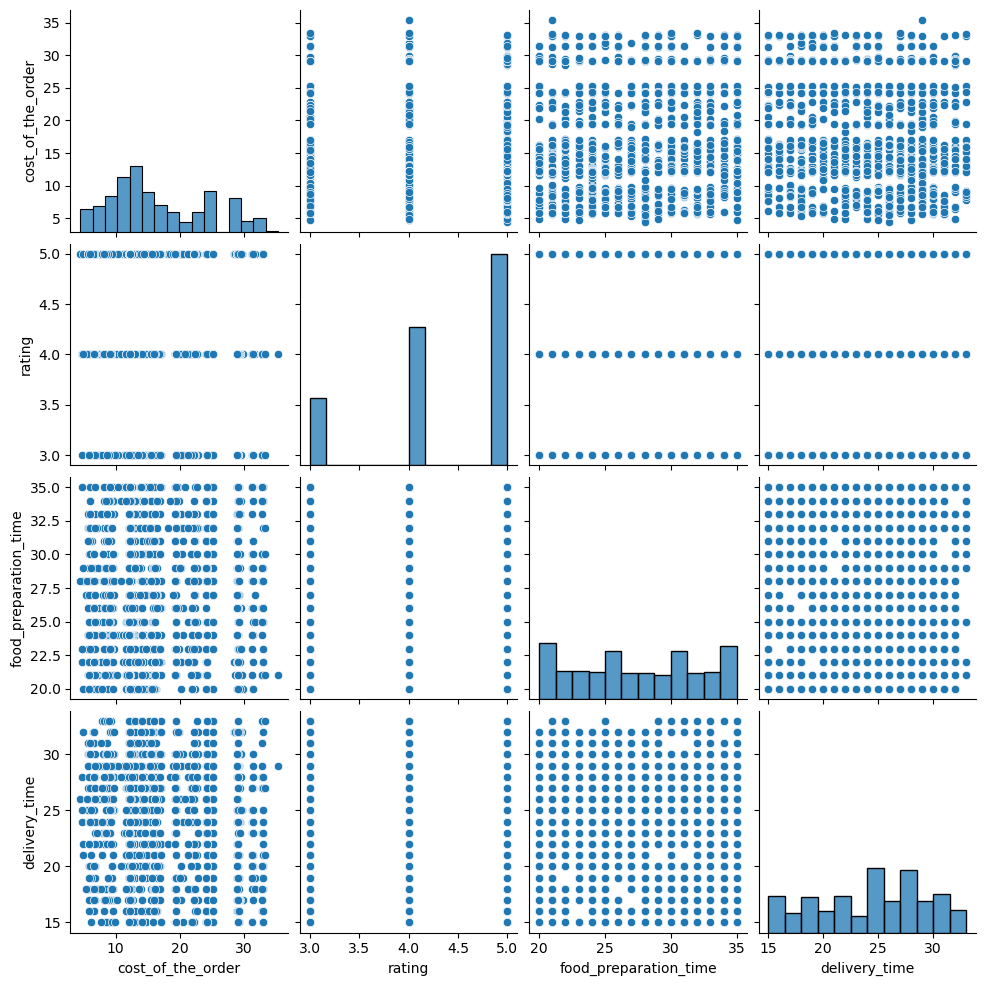

```python
#generate pairplot between numerical categories
sns.pairplot(data=df_shorten, vars=['cost_of_the_order', 'rating', 'food_preparation_time', 'delivery_time']);
```

#### Observations:

It seems like there are not particularly positive or negative correlation between the numerical categories. (With or without the orders that are not rated) We can also observe this through the heatmap below, which have correlation coefficients as close to zero between categories:

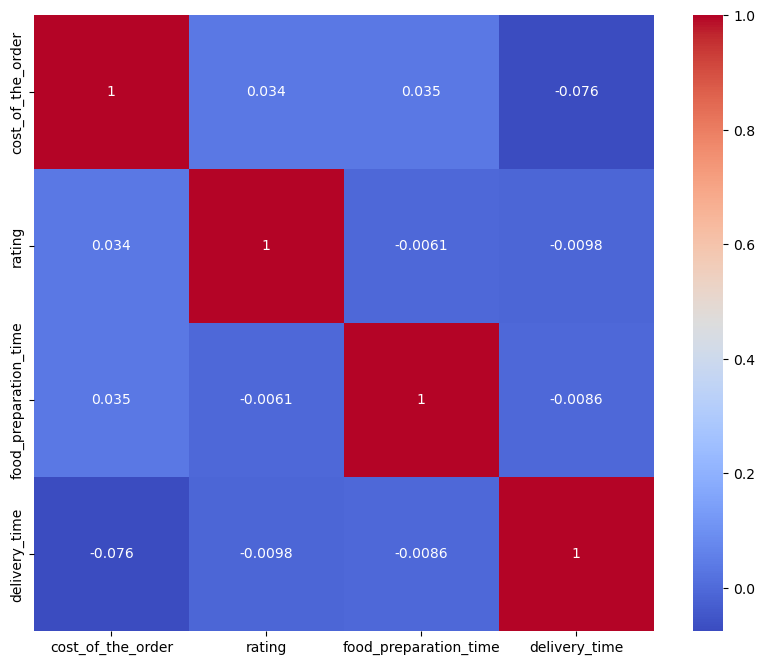

```python
# calculate correlation coefficients between numerical categories
df_shorten_corr = df_shorten[['cost_of_the_order', 'rating', 'food_preparation_time', 'delivery_time']].corr()

# generate a heatmapm, visualizing the correlation
plt.figure(figsize=(10,8)) # Set the size of the figure
sns.heatmap(df_shorten_corr, annot=True, cmap='coolwarm')
plt.show()
```

As for qualitative(string) categories, the most notable difference was noted in the day of the week. From univariate analysis, we noticed that there was a significantly greater number of orders placed during the weekends. So, here are some charts with added hue of day_of_the_week:

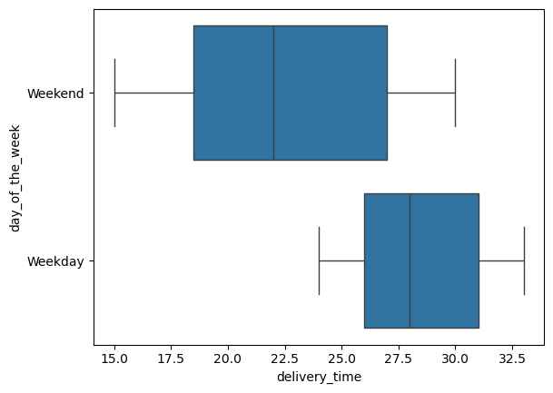

```python
# boxplot of delivery time, separated by day of the week
sns.boxplot(x="delivery_time", y="day_of_the_week", data=df);
```

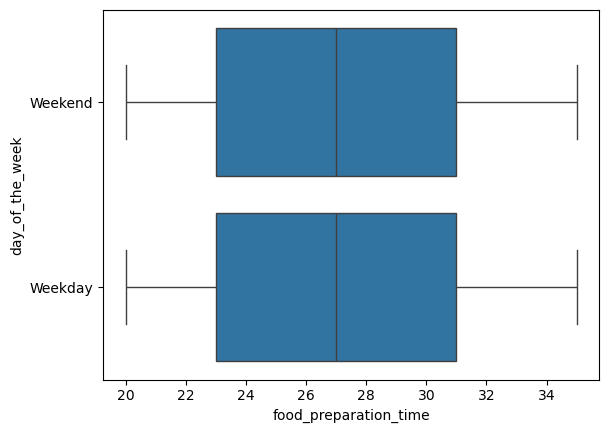

```python
# boxplot of food prep time, separated by day of the week
sns.boxplot(x="food_preparation_time", y="day_of_the_week", data=df);
```

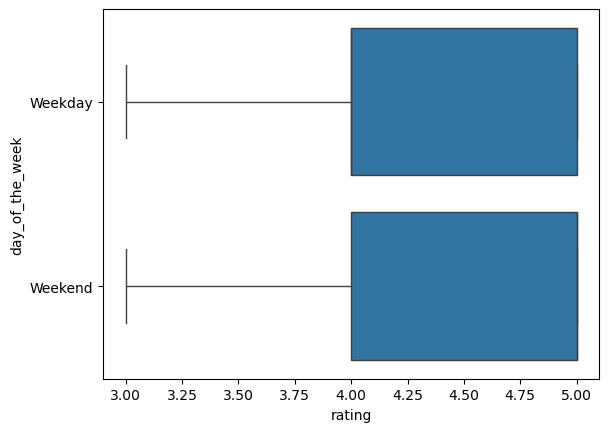

```python
# boxplot of rating, separated by day of the week

sns.boxplot(x="rating", y="day_of_the_week", data=df_shorten);
```

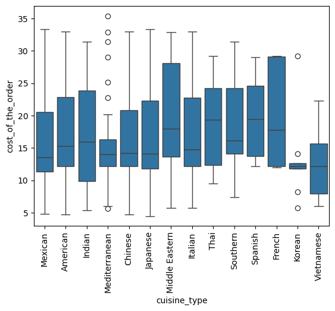

```python
# boxplots of cuisine types and the cost
sns.boxplot(x="cuisine_type", y="cost_of_the_order", data=df_shorten);
plt.xticks(rotation=90);
```

Mediterranean cuisine seems to have the highest costs, though the median is the highest for Thai and Spanish cuisines. Vietnamese is on the inexpensive side.

### **Question 13:** The company wants to provide a promotional offer in the advertisement of the restaurants. The condition to get the offer is that the restaurants must have a rating count of more than 50 and the average rating should be greater than 4. Find the restaurants fulfilling the criteria to get the promotional offer.

```python
# generate a groupby dataframe that extracts restaurant names and the number of their rated orders
number_of_ratings = df_shorten.groupby('restaurant_name')['rating'].count().reset_index()

# obtain the restaurants that also have more than 50 ratings
fifty_ratings = number_of_ratings[number_of_ratings['rating']>50]
fifty_ratings
```

|  | restaurant_name | rating |
| --- | --- | --- |
| 16 | Blue Ribbon Fried Chicken | 64 |
| 17 | Blue Ribbon Sushi | 73 |
| 117 | Shake Shack | 133 |
| 132 | The Meatball Shop | 84 |

```python
# take the mean of the ratings of each of the four restaurants that have more than 50 reviews.
df_shorten[df_shorten['restaurant_name']=='Blue Ribbon Fried Chicken']['rating'].mean()
print('Blue Ribbon Fried Chicken has the average rating of',df_shorten[df_shorten['restaurant_name']=='Blue Ribbon Fried Chicken']['rating'].mean() )

df_shorten[df_shorten['restaurant_name']=='Blue Ribbon Sushi']['rating'].mean()
print('Blue Ribbon Sushi has the average rating of',df_shorten[df_shorten['restaurant_name']=='Blue Ribbon Sushi']['rating'].mean() )

df_shorten[df_shorten['restaurant_name']=='Shake Shack']['rating'].mean()
print('Shake Shack has the average rating of',df_shorten[df_shorten['restaurant_name']=='Shake Shack']['rating'].mean() )

df_shorten[df_shorten['restaurant_name']=='The Meatball Shop']['rating'].mean()
print('The Meatball Shop has the average rating of',df_shorten[df_shorten['restaurant_name']=='The Meatball Shop']['rating'].mean() )
```

```
Blue Ribbon Fried Chicken has the average rating of 4.328125
Blue Ribbon Sushi has the average rating of 4.219178082191781
Shake Shack has the average rating of 4.2781954887218046
The Meatball Shop has the average rating of 4.511904761904762
```

#### Observations:

The restaurants fulfilling the criteria to get the promotional offer are:

Blue Ribbon Fried Chicken

Blue Ribbon Sushi

Shake Shack

The Meatball Shop

### **Question 14:** The company charges the restaurant 25% on the orders having cost greater than 20 dollars and 15% on the orders having cost greater than 5 dollars. Find the net revenue generated by the company across all orders.

```python
# calculate the total money paid by customers with orders over $20
total_twenty_plus = df[df['cost_of_the_order']>20]['cost_of_the_order'].sum()

# calculate the revenue (25%) for the company
revenue_twenty_plus = total_twenty_plus * 0.25
revenue_twenty_plus
```

```
3688.7275
```

```python
# calculate the total money paid by customers with orders over $5
total_five_plus = df[df['cost_of_the_order']>5]['cost_of_the_order'].sum() - total_twenty_plus

# calculate the revenue (15%) for the company
revenue_five_plus = total_five_plus * 0.15
revenue_five_plus
```

```
2477.5755000000004
```

```python
# add the two revenues
net_revenue = revenue_twenty_plus + revenue_five_plus
net_revenue
```

```
6166.303
```

#### Observations:

The net revenue generated by the company across all orders is approximately $6,166.30.

### **Question 15:** The company wants to analyze the total time required to deliver the food. What percentage of orders take more than 60 minutes to get delivered from the time the order is placed? (The food has to be prepared and then delivered.)

```python
# count how many orders have the combined time of more than 60 minutes between food prep and delivery
# then divide by the total number of orders, and multiply by 100 to make percent
len(df[df['food_preparation_time']+df['delivery_time']>60]) / len(df) *100
```

```
10.537407797681771
```

#### Observations:

Approximately 10.54% of the orders take more than 60 minutes to get delivered from the time the order is placed.

### **Question 16:** The company wants to analyze the delivery time of the orders on weekdays and weekends. How does the mean delivery time vary during weekdays and weekends?

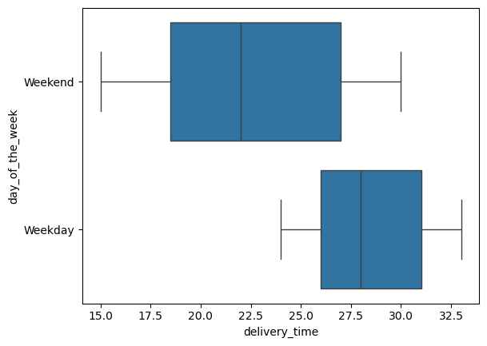

```python
# generate boxplot for comparison
sns.boxplot(x="delivery_time", y="day_of_the_week", data=df);
```

```python
#obtain the mean delivery time during the weekdays
df[df['day_of_the_week']=='Weekday']['delivery_time'].mean() #note that this does not include non-reviews
```

```
28.340036563071298
```

```python
#obtain the mean delivery time during the weekends
df[df['day_of_the_week']=='Weekend']['delivery_time'].mean() #note that this does not include non-reviews
```

```
22.4700222057735
```

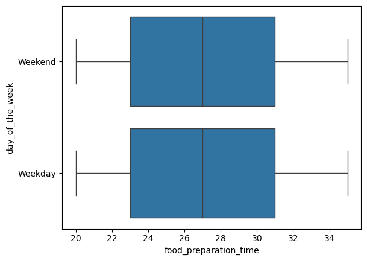

```python
# generate boxplot for food prep time to see if there is much difference
sns.boxplot(x="food_preparation_time", y="day_of_the_week", data=df);
```

#### Observations:

While the spread (IQR) for the delivery time during the weekend is greater, overall the delivery time during the weekday is significantly greater, on each of the summary items: min, Q1, median, Q3, max, and the mean.

The food prep time was also compared on the side, but there is not much difference in any of the summary items, which points out the need for delivery time improvements during the weekdays.

### **Question 17:** What are your conclusions from the analysis? What recommendations would you like to share to help improve the business? (You can use cuisine type and feedback ratings to drive your business recommendations.)

### Conclusions:

- More than 2/3 of the orders are placed during the weekend.
- The delivery times during the weekday are significantly longer than those during the weekends. This can be due to the lack of personnel or traffic.
- The most ordered cuisines are: American, Japanese, Italian, and Chinese.
- The most frequent customers are: 52832, 47440, and 83287.
- The most established restaurants with more than 50 ratings with the average greater than 4 are: Blue Ribbon Fried Chicken, Blue Ribbon Sushi, Shake Shack, and The Meatball Shop.
- The middle 50% of the order costs are around $12-22. This may mean that most customers order for one person.
- According to the data, there is close to no correlation between the numerical/quantitative variables (rating, cost, delivery time, and food prep time). This means that ratings will not necessarily be higher because of shorter delivery time or food prep time.